[figure not shown]

# Introduction to ML using Scikit-learn - II

Kannan Singaravelu

kannan.singaravelu@fitchlearning.com

# Linear Regression

Linear regression is an approach we use to model the relationship between a scalar dependent variable *`y`* and one or more explanatory variables (aka independent variables) denoted by *`X`*. In machine learning parlance, these explanatory variables or predictors are called **features** and target or the dependent variable **labels**. Regression modesl are models which predict a continuous outcome.

### Univariate Regression

The simplest possible relationship between two variables is a *`univariate regression`* when there is only one feature to be explained.

$$y_i \approx w_0 + w_1x_i$$

If we can measure some $(x_i, y_i)$ pairs, we could calculate our *model parameters* $w_0$ and $w_1$. Then we could predict $y$ in the future based on $x$, or even try to influence $y$ in the future by controlling $x$. This is achieved by minimizing the mean squared error,

$$L=\frac{1}{n} \sum_{i=1}^{n} \left(y_i - w_0 - \sum_{j=1}^{p} x_{ij}w_j \right)^2$$

### Multivariate Regression

If there multiple features that are to be mapped to a target variable, then it is a *`multivariate regression`* problem.

$$y_i \approx w_0 + w_1x_{1} + w_2x_{2} + w_3x_{3} + \cdots + w_nx_{n}$$

or more generally

$$y_i \approx \sum_jw_jX_{ij}$$

where $i$ labels different **observations** and $j$ labels different **features**.

## The workflow

We'll employ the following linear regressor from `scikit-learn` for median home price prediction.

- Linear Regression
- Lasso Regression
- Ridge Regression
- Elastic Net Regression

| Steps | Workflow | Remarks |
| --- | --- | --- |
| Step 1 | Ideation | Predict the median home price from the Boston housing dataset |
| Step 2 | Data Collection | Load the Boston housing dataset from scikit-learn |
| Step 3 | Exploratory Data Analysis | Study summary statistics |
| Step 4 | Cleaning Dataset | Data already cleaned, no further imputation required |
| Step 5 | Transformation | Perform feature scaling using StandardScaler |
| Step 6 | Modeling | Building and training linear regressor |
| Step 7 | Metrics | Validating the model performance using score method |

## Import Libraries

```python
# Data Manipulation
import numpy as np
import pandas as pd
import shap

# Visualizaiton
import matplotlib.pyplot as plt
plt.style.use('fivethirtyeight')

# Get Dataset from Scikit-learn
from sklearn.datasets import load_boston

# Data Preprocessing
from sklearn.model_selection import train_test_split
from sklearn.preprocessing import StandardScaler
from sklearn.pipeline import Pipeline

# Regressor
from sklearn.linear_model import LinearRegression, Lasso, Ridge, ElasticNet

# Metrics
from sklearn.metrics import mean_squared_error
```

## Load Data

```python
# Load data
boston_data = load_boston()
```

```python
# Subsume into a dataframe
boston = pd.DataFrame(boston_data['data'], columns=boston_data['feature_names'])
# Add target to the dataframe
boston['MEDV'] = boston_data.target

boston
```

|  | CRIM | ZN | INDUS | CHAS | NOX | RM | AGE | DIS | RAD | TAX | PTRATIO | B | LSTAT | MEDV |
| --- | --- | --- | --- | --- | --- | --- | --- | --- | --- | --- | --- | --- | --- | --- |
| 0 | 0.00632 | 18.0 | 2.31 | 0.0 | 0.538 | 6.575 | 65.2 | 4.0900 | 1.0 | 296.0 | 15.3 | 396.90 | 4.98 | 24.0 |
| 1 | 0.02731 | 0.0 | 7.07 | 0.0 | 0.469 | 6.421 | 78.9 | 4.9671 | 2.0 | 242.0 | 17.8 | 396.90 | 9.14 | 21.6 |
| 2 | 0.02729 | 0.0 | 7.07 | 0.0 | 0.469 | 7.185 | 61.1 | 4.9671 | 2.0 | 242.0 | 17.8 | 392.83 | 4.03 | 34.7 |
| 3 | 0.03237 | 0.0 | 2.18 | 0.0 | 0.458 | 6.998 | 45.8 | 6.0622 | 3.0 | 222.0 | 18.7 | 394.63 | 2.94 | 33.4 |
| 4 | 0.06905 | 0.0 | 2.18 | 0.0 | 0.458 | 7.147 | 54.2 | 6.0622 | 3.0 | 222.0 | 18.7 | 396.90 | 5.33 | 36.2 |
| ... | ... | ... | ... | ... | ... | ... | ... | ... | ... | ... | ... | ... | ... | ... |
| 501 | 0.06263 | 0.0 | 11.93 | 0.0 | 0.573 | 6.593 | 69.1 | 2.4786 | 1.0 | 273.0 | 21.0 | 391.99 | 9.67 | 22.4 |
| 502 | 0.04527 | 0.0 | 11.93 | 0.0 | 0.573 | 6.120 | 76.7 | 2.2875 | 1.0 | 273.0 | 21.0 | 396.90 | 9.08 | 20.6 |
| 503 | 0.06076 | 0.0 | 11.93 | 0.0 | 0.573 | 6.976 | 91.0 | 2.1675 | 1.0 | 273.0 | 21.0 | 396.90 | 5.64 | 23.9 |
| 504 | 0.10959 | 0.0 | 11.93 | 0.0 | 0.573 | 6.794 | 89.3 | 2.3889 | 1.0 | 273.0 | 21.0 | 393.45 | 6.48 | 22.0 |
| 505 | 0.04741 | 0.0 | 11.93 | 0.0 | 0.573 | 6.030 | 80.8 | 2.5050 | 1.0 | 273.0 | 21.0 | 396.90 | 7.88 | 11.9 |

506 rows × 14 columns

```python
# Define feature and target
X = boston.drop('MEDV', axis=1)      # Feature
y = boston['MEDV']                   # Label
```

```python
# Splitting the datasets into training and testing data.
X_train, X_test, y_train, y_test = train_test_split(X, y, test_size=0.2, random_state=0)

# Output the train and test data size
print(f"Train and Test Size {len(X_train)}, {len(X_test)}")
```

```
Train and Test Size 404, 102
```

```python
X_train.shape
```

```
(404, 13)
```

```python
X_train.head(2)
```

|  | CRIM | ZN | INDUS | CHAS | NOX | RM | AGE | DIS | RAD | TAX | PTRATIO | B | LSTAT |
| --- | --- | --- | --- | --- | --- | --- | --- | --- | --- | --- | --- | --- | --- |
| 220 | 0.35809 | 0.0 | 6.20 | 1.0 | 0.507 | 6.951 | 88.5 | 2.8617 | 8.0 | 307.0 | 17.4 | 391.70 | 9.71 |
| 71 | 0.15876 | 0.0 | 10.81 | 0.0 | 0.413 | 5.961 | 17.5 | 5.2873 | 4.0 | 305.0 | 19.2 | 376.94 | 9.88 |

## Linear Regression

In linear regression, the model coefficients are selected by minimizing a loss function.

```python
pipe = Pipeline([
    ('scaler', StandardScaler()),
    ('regressor', LinearRegression())
])
```

```python
# fit/train model
pipe.fit(X_train, y_train)

# predict labels
y_pred = pipe.predict(X_test)

# metrics
mse = mean_squared_error(y_test, y_pred)
rmse = np.sqrt(mse)

print(f'MSE: {mse:0.4}')
print(f'RMSE: {rmse:0.4}')
print(f'R^2 Train: {pipe.score(X_train, y_train):0.4}')
print(f'R^2 Test: {pipe.score(X_test, y_test):0.4}')
```

```
MSE: 33.45
RMSE: 5.784
R^2 Train: 0.773
R^2 Test: 0.5892
```

```python
y_pred.mean()
```

```
21.959397643961957
```

```python
pipe['regressor'].coef_
```

```
array([-0.97082019,  1.05714873,  0.03831099,  0.59450642, -1.8551476 ,
        2.57321942, -0.08761547, -2.88094259,  2.11224542, -1.87533131,
       -2.29276735,  0.71817947, -3.59245482])
```

```python
pipe['regressor'].intercept_
```

```
22.611881188118804
```

## Regularized Regression

If the coeficients are too large in linear regression, it can lead to overfitting the model. We do regularization to over come such issues that penalises large coefficients. Lasso and Ridge regression are penalty regression that prevent over-fitting from the simple linear regression.

### LASSO

The Least Absolute Shrinkage and Selection Operator (LASSO) is a variation of linear regression. In Lasso, the loss function is minimized by limiting the sum of absolute values of the model coefficients where the L1 penalty term is added to the Mean Square Error (MSE). The L1 penalty term not only shrinks the coefficents, but shrinks some of them to zero and that is very useful for feature selection.

$$L = \frac{1}{n} \sum_{i=1}^{n} \left(y_i - w_0 - \sum_{j=1}^{p} x_{ij}w_j \right)^2 + \lambda \sum_{j=1}^{p} {\mid w_j \mid}$$

where, $\lambda$ is the regularization penalty.

```python
laso = Pipeline([
    ('scaler', StandardScaler()),
    ('regressor', Lasso(alpha=0.1))
])
```

```python
# fit lasso model
laso.fit(X_train, y_train)
print(f'R^2 Train: {laso.score(X_train, y_train):0.4}')
print(f'R^2 Test: {laso.score(X_test, y_test):0.4}')
```

```
R^2 Train: 0.7677
R^2 Test: 0.5664
```

```python
laso['regressor'].coef_
```

```
array([-0.66346811,  0.70152397, -0.13072368,  0.5889339 , -1.35874893,
        2.72275426, -0.        , -2.14093195,  0.64085327, -0.65877899,
       -2.17221721,  0.60266575, -3.61579998])
```

```python
alpha_range = np.linspace(0.01,1,50)
# alpha_range = 10**np.linspace(2,-2,100)*0.5
la_coef = []

for i in alpha_range:
    laso = Pipeline([('scaler', StandardScaler()), ('regressor', Lasso(alpha=i))])
    laso.fit(X, y)
    la_coef.append(laso['regressor'].coef_)
```

```python
def plot_coeff(alpha_range, coef, modelname):

    # Plot Coefficients
    fig = plt.figure(figsize=(20,8))
    ax = plt.axes()

    ax.plot(alpha_range, coef)
    ax.set_xscale('log')
    ax.set_xlim(ax.get_xlim()[::-1])  # reverse axis
    ax.set_title(f'{modelname} coefficients as a function of the regularization')
    ax.set_xlabel('$\lambda$')
    ax.set_ylabel('$\mathbf{w}$')
```

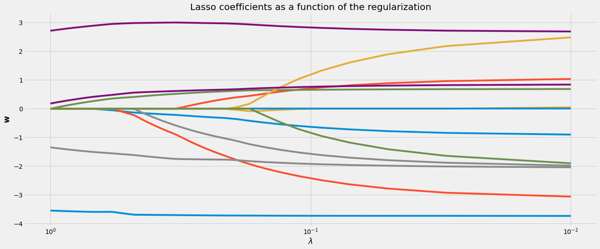

```python
# Plot Coefficients
plot_coeff(alpha_range, la_coef, 'Lasso')
```

### Ridge

In ridge regression, the cost function is altered by adding a L2 penality equivalent to square of the magnitude of the coefficients. The Ridge regression shrinks the coefficients and helps to reduce the multi-collinearity. As seen from the above graph, when $\lambda \xrightarrow {}0$, the cost function becomes similar to the linear regression cost function.

$$L = \frac{1}{n} \sum_{i=1}^{n} \left(y_i - w_0 - \sum_{j=1}^{p} x_{ij}w_j \right)^2 + \lambda \sum_{j=1}^{p} w_j^2$$

```python
rid = Pipeline([
    ('scaler', StandardScaler()),
    ('regressor', Ridge(alpha=1))
])
```

```python
# fit ridge model
rid.fit(X, y)
print(f'R^2 Train: {rid.score(X_train, y_train):0.4}')
print(f'R^2 Test: {rid.score(X_test, y_test):0.4}')
```

```
R^2 Train: 0.77
R^2 Test: 0.6184
```

```python
rid['regressor'].coef_
```

```
array([-0.91987132,  1.06646104,  0.11738487,  0.68512693, -2.02901013,
        2.68275376,  0.01315848, -3.07733968,  2.59153764, -2.0105579 ,
       -2.05238455,  0.84884839, -3.73066646])
```

```python
# alpha_range = np.arange(1,2000,100)
alpha_range = 10**np.linspace(6,-2,100)*0.5
rid_coef = []

for i in alpha_range:
    rid = Pipeline([('scaler', StandardScaler()), ('regressor', Ridge(alpha=i))])
    rid.fit(X, y)
    rid_coef.append(rid['regressor'].coef_)
```

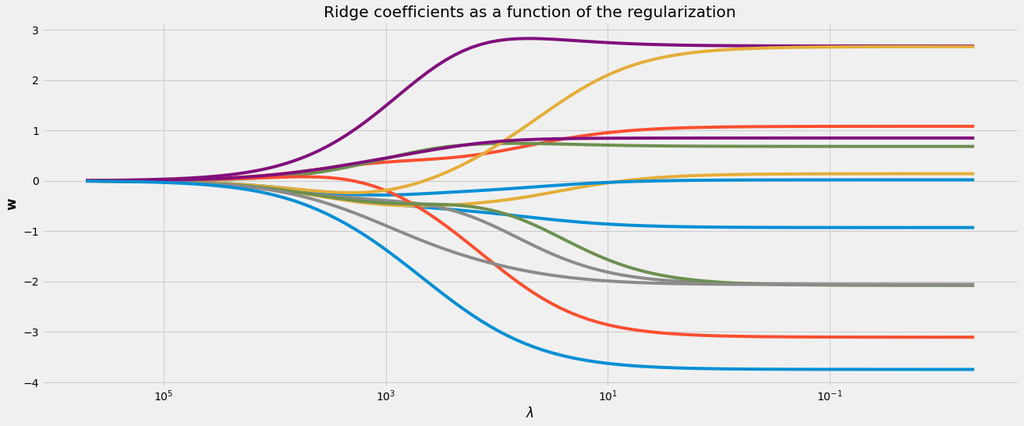

```python
# Plot Coefficients
plot_coeff(alpha_range, rid_coef, 'Ridge')
```

### ElasticNet Regression

ElasticNet combines the properties of both Lasso and Ridge regression. It penalizes the model using both the L1 and L2 norm.

$$L = \frac{1}{n} \sum_{i=1}^{n} \left(y_i - w_0 - \sum_{j=1}^{p} x_{ij}w_j \right)^2 + \lambda \left(\frac{1-\alpha}{2} \sum_{j=1}^{p} w_j^2 + \alpha \sum_{j=1}^{p} {\mid w_j\mid} \right)$$

where $0\leq \alpha \leq1$. Elastic net is same as lasso when $\alpha=1$ and ridge when $\alpha=0$. For other values of $\alpha$, the penalty term interpolate between L1 and L2 norm of the coefficient.

```python
elastic = Pipeline([
    ('scaler', StandardScaler()),
    ('regressor', ElasticNet(alpha=0.1, l1_ratio=0.5))
])
```

```python
# fit elasticnet model
elastic.fit(X_train, y_train)
print(f'R^2 Train: {elastic.score(X_train, y_train):0.4}')
print(f'R^2 Test: {elastic.score(X_test, y_test):0.4}')
```

```
R^2 Train: 0.7671
R^2 Test: 0.5617
```

```python
elastic['regressor'].coef_
```

```
array([-0.74093903,  0.72243247, -0.26704266,  0.62522263, -1.18854988,
        2.73484113, -0.09746715, -2.04841124,  0.7449307 , -0.78039169,
       -2.10099018,  0.66923402, -3.34109508])
```

```python
# alpha_range = np.linspace(0.01,15,150)
alpha_range = 10**np.linspace(2,-2,100)*0.5
elastic_coef = []

for i in alpha_range:
    elastic = Pipeline([('scaler', StandardScaler()), ('regressor', ElasticNet(alpha=i))])
    elastic.fit(X, y)
    elastic_coef.append(elastic['regressor'].coef_)
```

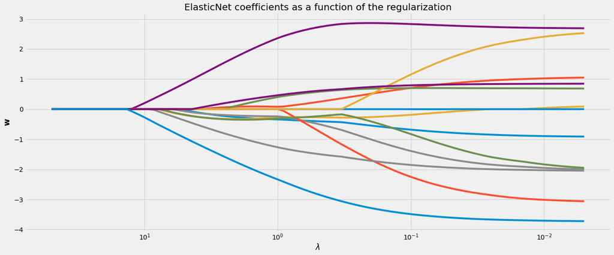

```python
# Plot Coefficients
plot_coeff(alpha_range, elastic_coef, 'ElasticNet')
```

## Features Selection

Feature selection methods are approaches to reduce the number of input variables that are believed to be most useful to a model. It is primarily focused on removing non-informative or redundant predictors from the model. We'll focus on few methods in relation to linear regression.

### Method 1: VIF

Multicollinearity occurs when two or more independent variables are highly correlated with one another in a regression model. This means that an independent variable can be predicted from another independent variable in a regression model.

Multicollinearity can be detected using various methods and one such method is Variable Inflation Factors (VIF). VIF determines the strength of the correlation between the independent variables. It is predicted by taking a variable and regressing it against every other variable.

VIF score of an independent variable represents how well the variable is explained by other independent variables.

R^2 value is determined to find out how well an independent variable is described by the other independent variables. A high value of R^2 means that the variable is highly correlated with the other variables. This is captured by the VIF which is denoted below:

$$VIF = \frac{1}{1-R^2}$$

- VIF starts at 1 and has no upper limit
- VIF = 1, no correlation between the independent variable and the other variables
- VIF exceeding 5 or 10 indicates high multicollinearity between this independent variable and the others

```python
# Import VIF
from statsmodels.stats.outliers_influence import variance_inflation_factor
```

```python
# For each X, calculate VIF and save in dataframe
def vif(X):

    # perform feature scaling
    scaler = StandardScaler()
    xs = scaler.fit_transform(X)

    # subsume into a dataframe
    vif = pd.DataFrame()
    vif["Features"] = X.columns
    vif["VIF Factor"] = [variance_inflation_factor(xs, i) for i in range(xs.shape[1])]

    return vif
```

```python
# List scores
vif(X).round(2)
```

|  | Features | VIF Factor |
| --- | --- | --- |
| 0 | CRIM | 1.79 |
| 1 | ZN | 2.30 |
| 2 | INDUS | 3.99 |
| 3 | CHAS | 1.07 |
| 4 | NOX | 4.39 |
| 5 | RM | 1.93 |
| 6 | AGE | 3.10 |
| 7 | DIS | 3.96 |
| 8 | RAD | 7.48 |
| 9 | TAX | 9.01 |
| 10 | PTRATIO | 1.80 |
| 11 | B | 1.35 |
| 12 | LSTAT | 2.94 |

```python
# Drop VIF score > 5
newX = X.drop(['TAX', 'RAD'],axis=1)
```

```python
# Scores in ascending values
vif(newX).sort_values(by="VIF Factor")
```

|  | Features | VIF Factor |
| --- | --- | --- |
| 3 | CHAS | 1.057805 |
| 9 | B | 1.316559 |
| 0 | CRIM | 1.478206 |
| 8 | PTRATIO | 1.496077 |
| 5 | RM | 1.872532 |
| 1 | ZN | 2.154483 |
| 10 | LSTAT | 2.936487 |
| 6 | AGE | 3.075755 |
| 2 | INDUS | 3.179166 |
| 4 | NOX | 3.901348 |
| 7 | DIS | 3.954443 |

```python
# Filter first six features
X_method1 = X[['CHAS', 'B', 'CRIM', 'PTRATIO', 'RM', 'ZN']]
```

```python
# fit/train model
pipe.fit(X_method1, y)

# predict labels
y_pred = pipe.predict(X_method1)

print(y_pred[:10])
print(f'R^2: {pipe.score(X_method1, y):0.4}')
```

```
[28.57799551 24.78825544 30.16715122 28.03678666 29.13085894 23.98038835
 24.50415657 25.65810523 21.62521274 24.29070206]
R^2: 0.6273
```

### Method 2: SelectKBest

Select features according to the k highest scores. Univariate feature selection works by selecting the best features based on univariate statistical tests.

```python
# Feature Selection
from sklearn.feature_selection import f_regression, SelectKBest, SelectPercentile
```

```python
# SelectKBest
# selector1 = SelectPercentile(f_regression, percentile=25)
method2 =  SelectKBest(f_regression, k=6)

# Fit the model
method2.fit(X,y)
```

```
SelectKBest(k=6, score_func=<function f_regression at 0x169f2c9d8>)
```

```python
# Show selected features
method2.get_support(indices=True)
```

```
array([ 2,  4,  5,  9, 10, 12])
```

```python
# Iterate the score
for f, s in zip(X.columns, method2.scores_):
    print(f'F-score: {s:0.4} for feature {f}')
```

```
F-score: 89.49 for feature CRIM
F-score: 75.26 for feature ZN
F-score: 154.0 for feature INDUS
F-score: 15.97 for feature CHAS
F-score: 112.6 for feature NOX
F-score: 471.8 for feature RM
F-score: 83.48 for feature AGE
F-score: 33.58 for feature DIS
F-score: 85.91 for feature RAD
F-score: 141.8 for feature TAX
F-score: 175.1 for feature PTRATIO
F-score: 63.05 for feature B
F-score: 601.6 for feature LSTAT
```

```python
# Filter six features with highest score
X_method2 = X[['INDUS', 'NOX', 'RM', 'TAX', 'PTRATIO', 'LSTAT']]
```

```python
# fit/train model
pipe.fit(X_method2, y)

# predict labels
y_pred = pipe.predict(X_method2)

print(y_pred[:10])
print(f'R^2: {pipe.score(X_method2, y):0.4}')
```

```
[30.57014999 26.10398705 32.45084162 31.0219246  30.41087418 27.1380861
 24.46192059 21.5381886  13.13415681 21.87515864]
R^2: 0.681
```

```python
# check the coefficients
pipe['regressor'].coef_
```

```
array([ 0.59754458, -0.39395547,  3.26810054, -0.48846049, -1.9764135 ,
       -3.89469824])
```

### Method 3: RFE

Feature ranking with recursive feature elimination (RFE). The goal is to select features by recursively considering smaller and smaller sets of features.

```python
# Feature Selection using RFE
from sklearn.feature_selection import RFECV, RFE
```

```python
# Method 3
method3 = RFE(LinearRegression(), n_features_to_select=6, step=1)
method3.fit(X,y)
```

```
RFE(estimator=LinearRegression(), n_features_to_select=6)
```

```python
# Check the selected position
method3.support_
```

```
array([False, False, False,  True,  True,  True, False,  True, False,
       False,  True, False,  True])
```

```python
# Get the feature ranking
method3.ranking_
```

```
array([3, 5, 4, 1, 1, 1, 8, 1, 2, 6, 1, 7, 1])
```

```python
# Select Six Features
min_value = min(method3.ranking_)
col = [i for i, x in enumerate(method3.ranking_) if x == min_value]
col
```

```
[3, 4, 5, 7, 10, 12]
```

```python
# Filter selected features
X_method3 = X[['CHAS', 'NOX', 'RM', 'DIS', 'PTRATIO', 'LSTAT']]
```

```python
# fit/train model
pipe.fit(X_method3, y)

# predict labels
y_pred = pipe.predict(X_method3)

print(y_pred[:10])
print(f'R^2: {pipe.score(X_method3, y):0.4}')
```

```
[31.0142456  25.79278275 31.84611084 29.74856961 28.99930186 26.11951419
 23.13348366 19.51563196 10.99759368 19.25866209]
R^2: 0.7158
```

```python
# check the coefficients
pipe['regressor'].coef_
```

```
array([ 0.82321941, -2.16945087,  2.88617319, -2.40778286, -2.16874483,
       -4.06526959])
```

### Method 4: RFECV

A recursive feature elimination with automatic tuning of the number of features selected with cross-validation.

```python
# Method 4
method4 = RFECV(LinearRegression(), cv=10)
method4.fit(X,y)
```

```
RFECV(cv=10, estimator=LinearRegression())
```

```python
# Get the selected features with CV
method4.n_features_
```

```
6
```

```python
# Get the index of the selected features
method4.get_support(indices=True)
```

```
array([ 3,  4,  5,  7, 10, 12])
```

```python
# Check the selected position
method4.support_
```

```
array([False, False, False,  True,  True,  True, False,  True, False,
       False,  True, False,  True])
```

```python
# Get the feature ranking
method4.ranking_
```

```
array([3, 5, 4, 1, 1, 1, 8, 1, 2, 6, 1, 7, 1])
```

```python
# Select Six Features
min_value = min(method4.ranking_)
col = [i for i, x in enumerate(method4.ranking_) if x == min_value]
col
```

```
[3, 4, 5, 7, 10, 12]
```

```python
# Iterate to get features
for i in range(len(col)):
    print(X.columns[col[i]])
```

```
CHAS
NOX
RM
DIS
PTRATIO
LSTAT
```

```python
# Filter selected features
X_method4 = X[['CHAS', 'NOX', 'RM', 'DIS', 'PTRATIO', 'LSTAT']]
```

```python
# fit/train model
pipe.fit(X_method4, y)

# predict labels
y_pred = pipe.predict(X_method4)

print(y_pred[:10])
print(f'R^2: {pipe.score(X_method4, y):0.4}')
```

```
[31.0142456  25.79278275 31.84611084 29.74856961 28.99930186 26.11951419
 23.13348366 19.51563196 10.99759368 19.25866209]
R^2: 0.7158
```

```python
# check the coefficients
pipe['regressor'].coef_
```

```
array([ 0.82321941, -2.16945087,  2.88617319, -2.40778286, -2.16874483,
       -4.06526959])
```

### Method 5: SHAP

SHAP (SHapley Additive exPlanations) is a game theoretic approach to explain the output of any machine learning model. It connects optimal credit allocation with local explanations using the classic Shapley values from game theory and their related extensions.

Shapley values are a widely used approach from cooperative game theory that come with desirable properties and is the average marginal contribution of a feature value across all possible coalitions.

```python
# 100 instances for use as the background distribution
X100 = shap.utils.sample(X, 100, random_state=42)
pipe.fit(X, y)
```

```
Pipeline(steps=[('scaler', StandardScaler()),
                ('regressor', LinearRegression())])
```

```python
# compute the SHAP values for the linear model
explainer = shap.Explainer(pipe.predict, X100)
shap_values = explainer(X)
```

```
Permutation explainer: 507it [00:18, 19.20it/s]
```

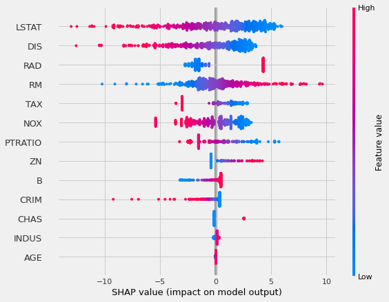

```python
shap.plots.beeswarm(shap_values, max_display=14)
```

The above plot shows the feature importance of a linear model where the variables are ranked in descending order and the horizontal location shows whether the effect of that value is associated with a higher or lower prediction.

```python
# Filter selected features
X_method5 = X[['LSTAT', 'DIS', 'RM', 'PTRATIO', 'CRIM']]
```

```python
# fit/train model
pipe.fit(X_method5, y)

# predict labels

y_pred = pipe.predict(X_method5)

print(y_pred[:10])
print(f'R^2: {pipe.score(X_method5, y):0.4}')
```

```
[31.63761273 25.5236182  32.0243847  30.38600726 29.5358719  26.50795486
 23.71933951 19.96956586 10.8068779  20.1215183 ]
R^2: 0.6958
```

### Comparision

Given the boston housing dataset is a processed data, there seems to be no improvement in the score on feature reduction.

| Feature Selection Method | R-Square | Improvement |
| --- | --- | --- |
| Original Features set | 0.7406 | ----- |
| VIF | 0.6273 | -0.15298 |
| SelectKBest | 0.6810 | -0.08047 |
| RFE | 0.7158 | -0.03348 |
| RFECV | 0.7158 | -0.03348 |
| SHAP | 0.6958 | -0.06049 |

Alternatively, one might split the data into train and test sets to study the impact of over or under fitting of the model. The Recursive Feature Elimination is closer to the original scoring with just six features while the impact of each of these features is explained by the SHAP values.

# References

- [Scikit-learn Documentation](https://scikit-learn.org/stable/index.html)
- [Scikit-learn API Reference](https://scikit-learn.org/stable/modules/classes.html)
- [Python Resources](https://github.com/kannansingaravelu/PythonResources)
- Jake VanderPlas (2017), Python Data Science Handbook

[Kannan Singaravelu](https://github.com/kannansingaravelu)  
Certificate in Quantitative Finance, June 2021